# Critcal CSS experiment - Data analysis

### CPU Utilisation

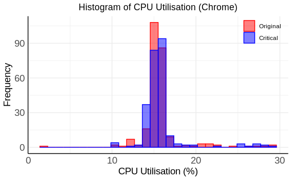

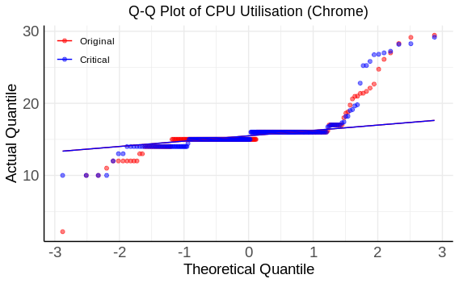

```r
plot_hist_qq(chrome_data, 'cpu_usage', "CPU Utilisation", "%", 'Chrome')
```

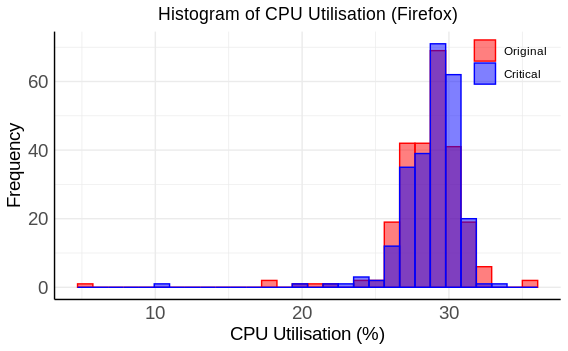

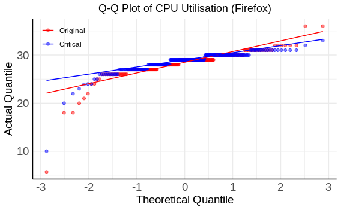

```r
plot_hist_qq(firefox_data, 'cpu_usage', "CPU Utilisation", "%", 'Firefox')
```

In the above plots we observe some outliers, which we will *not* remove, to prevent potential bias. The actual quantiles seem to diverge from the theoretical quantiles, especially for Chrome, so we do not think these measures follow a normal distribution. To confirm, let us compute the skewness and perform a shapiro-wilk test.

```r
skewness_and_shapiro(chrome_data, 'cpu_usage')
```

```
[1] "Skewness critical: 3.01039400494691"
[1] "Skewness original: 1.99780638703773"

    Shapiro-Wilk normality test

data:  data[data$critical == TRUE, ][[column]]
W = 0.59727, p-value < 2.2e-16


    Shapiro-Wilk normality test

data:  data[data$critical == FALSE, ][[column]]
W = 0.63066, p-value < 2.2e-16
```

```r
skewness_and_shapiro(firefox_data, 'cpu_usage')
```

```
[1] "Skewness critical: -3.5666427547807"
[1] "Skewness original: -3.40364070740577"

    Shapiro-Wilk normality test

data:  data[data$critical == TRUE, ][[column]]
W = 0.75061, p-value < 2.2e-16


    Shapiro-Wilk normality test

data:  data[data$critical == FALSE, ][[column]]
W = 0.73839, p-value < 2.2e-16
```

To compensate for the skewness, let us consider transforming the data using log, square root and reciprocal transformations. All are suitable for positively skewed data.

First, for chrome:

```
[1] "SQRT"
[1] "Skewness critical: 2.47571715520802"
[1] "Skewness original: -0.124966281074114"

    Shapiro-Wilk normality test

data:  data[data$critical == TRUE, ][[column]]
W = 0.64726, p-value < 2.2e-16


    Shapiro-Wilk normality test

data:  data[data$critical == FALSE, ][[column]]
W = 0.63211, p-value < 2.2e-16

[1] "LOG"
[1] "Skewness critical: 1.82607755808206"
[1] "Skewness original: -4.18266599103346"

    Shapiro-Wilk normality test

data:  data[data$critical == TRUE, ][[column]]
W = 0.69067, p-value < 2.2e-16


    Shapiro-Wilk normality test

data:  data[data$critical == FALSE, ][[column]]
W = 0.54079, p-value < 2.2e-16

[1] "INV"
[1] "Skewness critical: -0.191127243469478"
[1] "Skewness original: 13.447334284067"

    Shapiro-Wilk normality test

data:  data[data$critical == TRUE, ][[column]]
W = 0.73672, p-value < 2.2e-16


    Shapiro-Wilk normality test

data:  data[data$critical == FALSE, ][[column]]
W = 0.19575, p-value < 2.2e-16
```

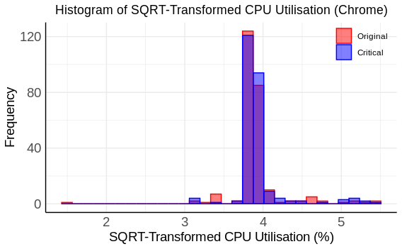

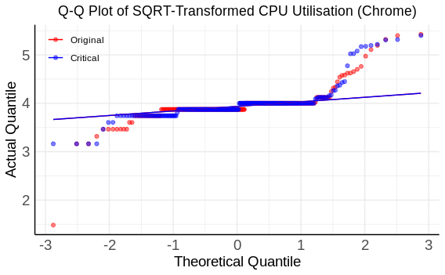

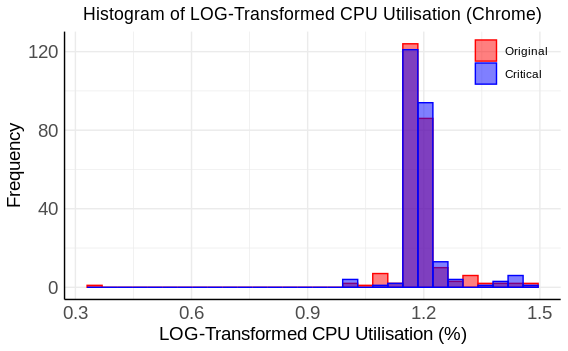

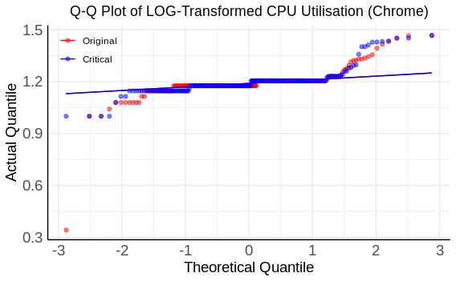

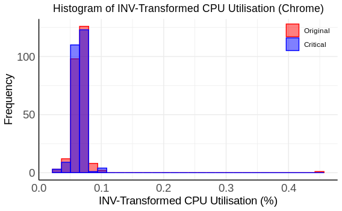

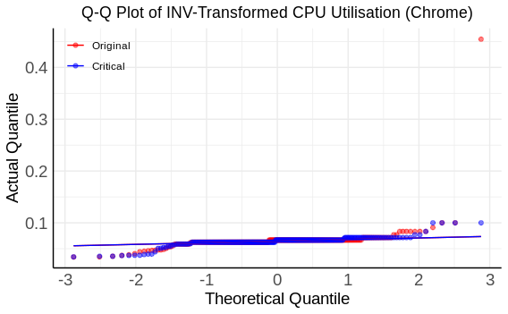

```r
transform_and_test(chrome_data, 'cpu_usage', "CPU Utilisation", "%", 'Chrome')
```

Then firefox:

```
[1] "SQRT"
[1] "Skewness critical: -4.91176038666559"
[1] "Skewness original: -5.40303870328901"

    Shapiro-Wilk normality test

data:  data[data$critical == TRUE, ][[column]]
W = 0.66943, p-value < 2.2e-16


    Shapiro-Wilk normality test

data:  data[data$critical == FALSE, ][[column]]
W = 0.62382, p-value < 2.2e-16

[1] "LOG"
[1] "Skewness critical: -6.65369578260194"
[1] "Skewness original: -8.1127908429083"

    Shapiro-Wilk normality test

data:  data[data$critical == TRUE, ][[column]]
W = 0.57015, p-value < 2.2e-16


    Shapiro-Wilk normality test

data:  data[data$critical == FALSE, ][[column]]
W = 0.47678, p-value < 2.2e-16

[1] "INV"
[1] "Skewness critical: 10.6916790265126"
[1] "Skewness original: 13.2783460116322"

    Shapiro-Wilk normality test

data:  data[data$critical == TRUE, ][[column]]
W = 0.35281, p-value < 2.2e-16


    Shapiro-Wilk normality test

data:  data[data$critical == FALSE, ][[column]]
W = 0.20555, p-value < 2.2e-16
```

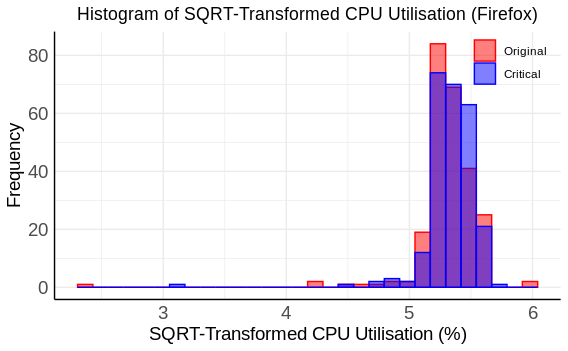

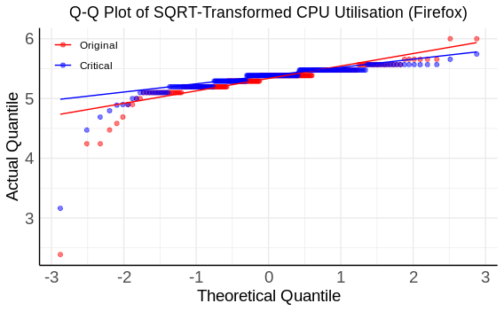

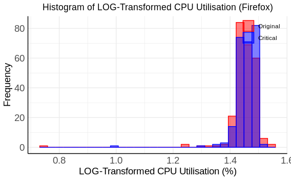

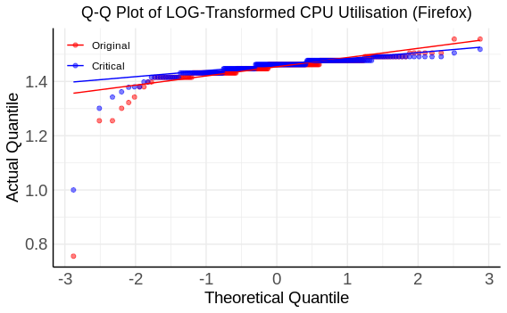

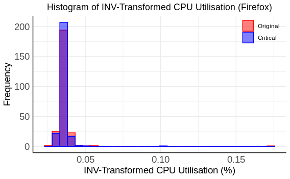

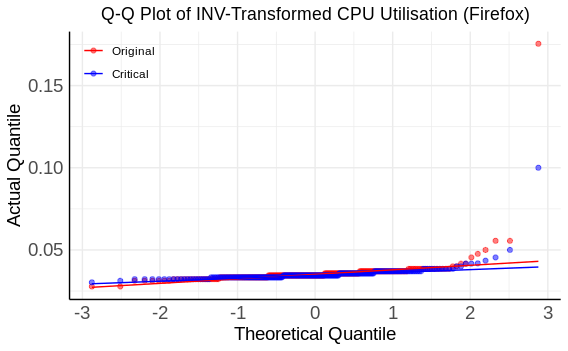

```r
transform_and_test(firefox_data, 'cpu_usage', "CPU Utilisation", "%", 'Firefox')
```

As it turns out, none of the sets of measures seem to follow a normal distribution. We therefore perform only non-parametric tests. Let us consider the Wilcoxon non-parametric rank-based test.

```r
wilcox.test(chrome_data[chrome_data$critical == TRUE,]$cpu_usage, chrome_data[chrome_data$critical == FALSE,]$cpu_usage)
```

```
    Wilcoxon rank sum test with continuity correction

data:  chrome_data[chrome_data$critical == TRUE, ]$cpu_usage and chrome_data[chrome_data$critical == FALSE, ]$cpu_usage
W = 31240, p-value = 0.9948
alternative hypothesis: true location shift is not equal to 0
```

```r
wilcox.test(firefox_data[firefox_data$critical == TRUE,]$cpu_usage, firefox_data[firefox_data$critical == FALSE,]$cpu_usage)
```

```
    Wilcoxon rank sum test with continuity correction

data:  firefox_data[firefox_data$critical == TRUE, ]$cpu_usage and firefox_data[firefox_data$critical == FALSE, ]$cpu_usage
W = 33831, p-value = 0.1032
alternative hypothesis: true location shift is not equal to 0
```

For both chrome and firefox the Wilcoxon test yields a p-value > 0.05, meaning that we cannot reject H0 that the difference between pairs follows a symmetric distribution around zero. Hence, we are not able to claim that web apps with or without application of the Critical CSS Technique differ in their CPU utilisation on our mobile device.

### Memory Utilisation

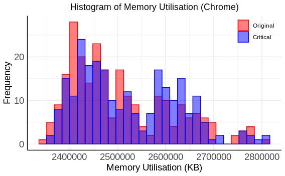

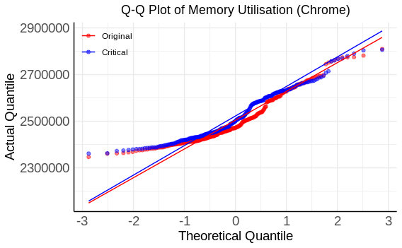

```r
plot_hist_qq(chrome_data, 'memory_usage', "Memory Utilisation", "KB", 'Chrome')
```

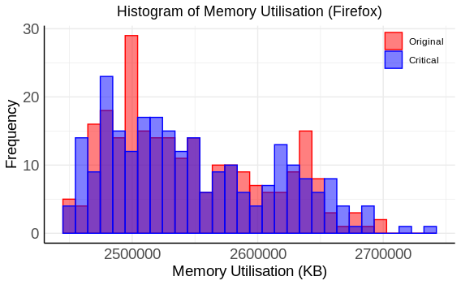

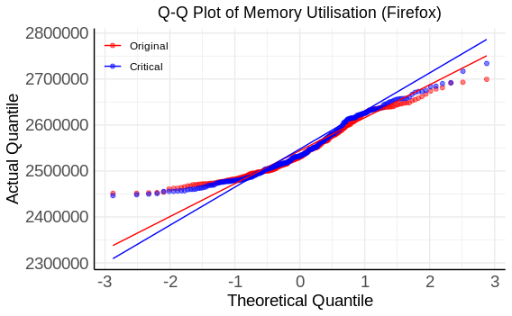

```r
plot_hist_qq(firefox_data, 'memory_usage', "Memory Utilisation", "KB", 'Firefox')
```

In the above plots we observe some outliers, which we will *not* remove, to prevent potential bias. The actual quantiles seem to diverge from the theoretical quantiles, especially for Chrome, so we do not think these measures follow a normal distribution. To confirm, let us compute the skewness and perform a shapiro-wilk test.

```r
skewness_and_shapiro(chrome_data, 'memory_usage')
```

```
[1] "Skewness critical: 0.514292982528306"
[1] "Skewness original: 0.820347816282102"

    Shapiro-Wilk normality test

data:  data[data$critical == TRUE, ][[column]]
W = 0.94493, p-value = 4.291e-08


    Shapiro-Wilk normality test

data:  data[data$critical == FALSE, ][[column]]
W = 0.91916, p-value = 2.085e-10
```

```r
skewness_and_shapiro(firefox_data, 'memory_usage')
```

```
[1] "Skewness critical: 0.505675679610085"
[1] "Skewness original: 0.523346008882094"

    Shapiro-Wilk normality test

data:  data[data$critical == TRUE, ][[column]]
W = 0.94806, p-value = 9.044e-08


    Shapiro-Wilk normality test

data:  data[data$critical == FALSE, ][[column]]
W = 0.93918, p-value = 1.165e-08
```

For both chrome and firefox and both the original and critical versions of the web apps, a positive skewness is observed. Also, all shapiro-wilk test results yield a p-value < 0.05, meaning that we can reject H0 that these measures originate from a normal distribution.

To compensate for the skewness, let us consider transforming the data using log, square root and reciprocal transformations. All are suitable for positively skewed data.

First, for chrome:

```
[1] "SQRT"
[1] "Skewness critical: 0.480776642470112"
[1] "Skewness original: 0.786235182453957"

    Shapiro-Wilk normality test

data:  data[data$critical == TRUE, ][[column]]
W = 0.94707, p-value = 7.126e-08


    Shapiro-Wilk normality test

data:  data[data$critical == FALSE, ][[column]]
W = 0.92294, p-value = 4.229e-10

[1] "LOG"
[1] "Skewness critical: 0.447977660192565"
[1] "Skewness original: 0.752598171548798"

    Shapiro-Wilk normality test

data:  data[data$critical == TRUE, ][[column]]
W = 0.94905, p-value = 1.148e-07


    Shapiro-Wilk normality test

data:  data[data$critical == FALSE, ][[column]]
W = 0.92656, p-value = 8.5e-10

[1] "INV"
[1] "Skewness critical: -0.384408643050623"
[1] "Skewness original: -0.686692812613337"

    Shapiro-Wilk normality test

data:  data[data$critical == TRUE, ][[column]]
W = 0.95249, p-value = 2.713e-07


    Shapiro-Wilk normality test

data:  data[data$critical == FALSE, ][[column]]
W = 0.93331, p-value = 3.32e-09
```

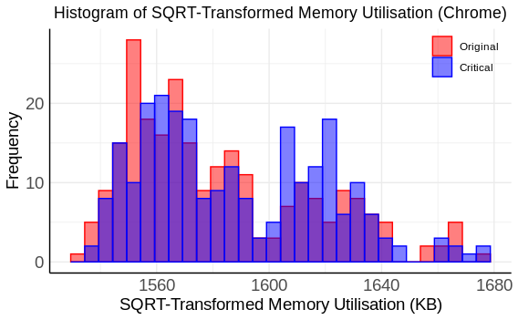

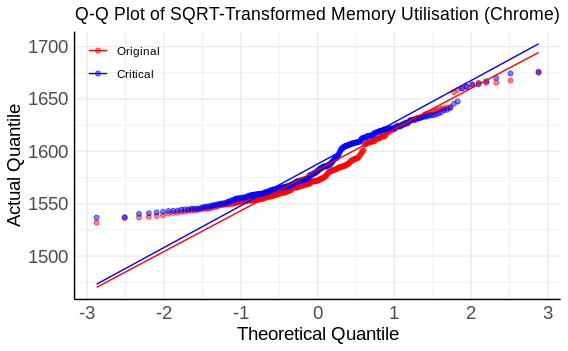

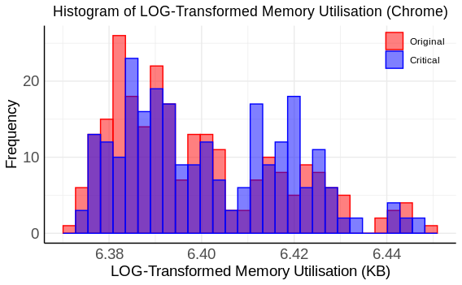

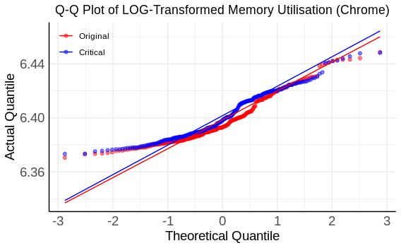

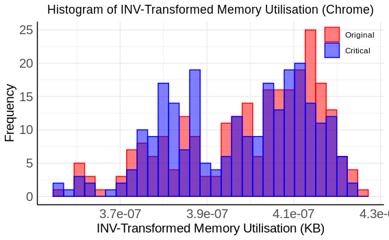

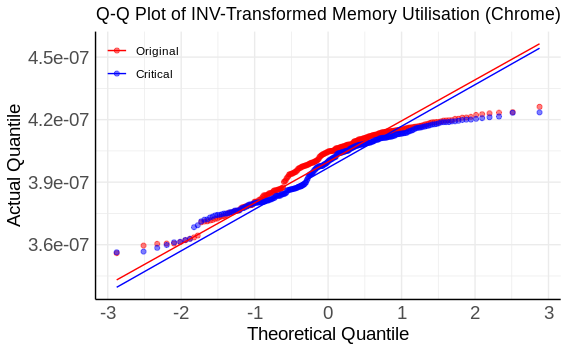

```r
transform_and_test(chrome_data, 'memory_usage', "Memory Utilisation", "KB", 'Chrome')
```

Then firefox:

```
[1] "SQRT"
[1] "Skewness critical: 0.486728587597314"
[1] "Skewness original: 0.507380752116659"

    Shapiro-Wilk normality test

data:  data[data$critical == TRUE, ][[column]]
W = 0.94943, p-value = 1.262e-07


    Shapiro-Wilk normality test

data:  data[data$critical == FALSE, ][[column]]
W = 0.94052, p-value = 1.57e-08

[1] "LOG"
[1] "Skewness critical: 0.46791702124599"
[1] "Skewness original: 0.491477766702412"

    Shapiro-Wilk normality test

data:  data[data$critical == TRUE, ][[column]]
W = 0.95074, p-value = 1.745e-07


    Shapiro-Wilk normality test

data:  data[data$critical == FALSE, ][[column]]
W = 0.94183, p-value = 2.104e-08

[1] "INV"
[1] "Skewness critical: -0.430683697571069"
[1] "Skewness original: -0.459852805549312"

    Shapiro-Wilk normality test

data:  data[data$critical == TRUE, ][[column]]
W = 0.95319, p-value = 3.243e-07


    Shapiro-Wilk normality test

data:  data[data$critical == FALSE, ][[column]]
W = 0.94431, p-value = 3.714e-08
```

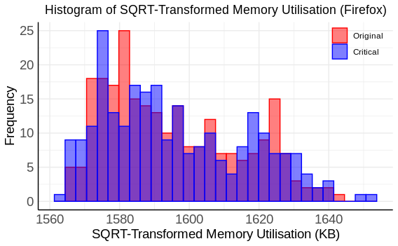

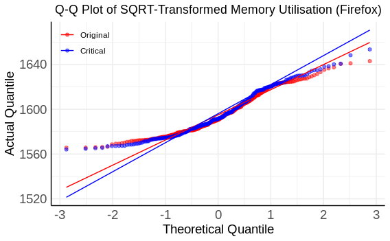

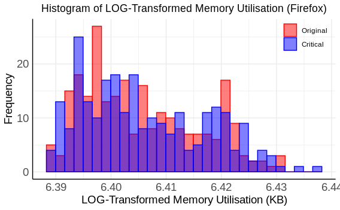

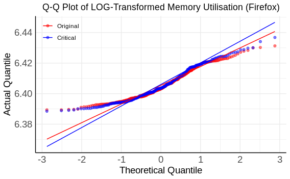

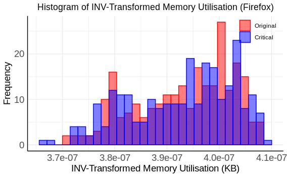

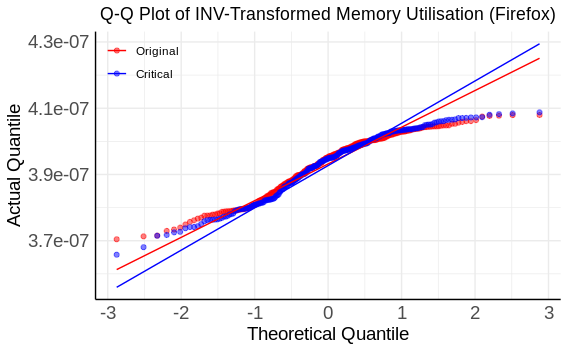

```r
transform_and_test(firefox_data, 'memory_usage', "Memory Utilisation", "KB", 'Firefox')
```

As it turns out, none of the sets of measures seem to follow a normal distribution. We therefore perform only non-parametric tests. Let us consider the Wilcoxon non-parametric rank-based test.

```r
wilcox.test(chrome_data[chrome_data$critical == TRUE,]$memory_usage, chrome_data[chrome_data$critical == FALSE,]$memory_usage)
```

```
    Wilcoxon rank sum test with continuity correction

data:  chrome_data[chrome_data$critical == TRUE, ]$memory_usage and chrome_data[chrome_data$critical == FALSE, ]$memory_usage
W = 34592, p-value = 0.03859
alternative hypothesis: true location shift is not equal to 0
```

```r
wilcox.test(firefox_data[firefox_data$critical == TRUE,]$memory_usage, firefox_data[firefox_data$critical == FALSE,]$memory_usage)
```

```
    Wilcoxon rank sum test with continuity correction

data:  firefox_data[firefox_data$critical == TRUE, ]$memory_usage and firefox_data[firefox_data$critical == FALSE, ]$memory_usage
W = 31539, p-value = 0.8583
alternative hypothesis: true location shift is not equal to 0
```

For firefox the Wilcoxon test yields a p-value > 0.05, meaning that we cannot reject H0 that the difference between pairs follows a symmetric distribution around zero. Hence, we are not able to claim that web apps with or without application of the Critical CSS Technique differ in their memory utilisation while using firefox on our mobile device.

For chrome on the other hand, the Wilcoxon test yields a p-value < 0.05, meaning that we reject H0 that the difference between pairs follows a symmetric distribution around zero. Hence, we are able to claim that web apps with or without application of the Critical CSS Technique differ in their memory utilisation while using chrome on our mobile device.

#### Effect size

To quantify the impact of Critical CSS on memory utilisation, we compute Cliff’s delta effect size measure to the data related to the memory utilisation of the web apps.

```r
cliff.delta(chrome_data[chrome_data$critical == TRUE,]$memory_usage, chrome_data[chrome_data$critical == FALSE,]$memory_usage)
```

```
Cliff's Delta

delta estimate: 0.106944 (negligible)
95 percent confidence interval:
      lower       upper
0.005674323 0.206042337
```

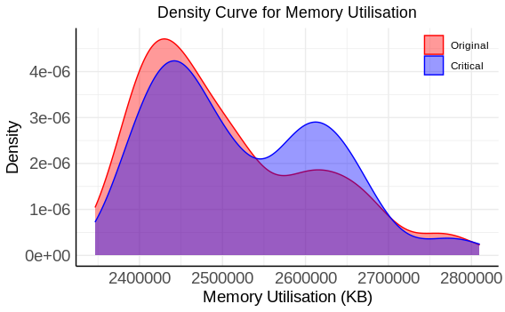

```r
ggplot(chrome_data, group=critical) + theme_minimal() + scale_color_manual(labels=c('Original', 'Critical'), values=c('red', 'blue')) + scale_fill_manual(labels=c('Original', 'Critical'), values=c('red', 'blue')) + theme_minimal() + ggtitle('Density Curve for Memory Utilisation') + xlab('Memory Utilisation (KB)') + ylab('Density') +
  theme(plot.title = element_text(hjust = 0.5),
        axis.text.y = element_text(size=14),
        axis.text.x   = element_text(size=14),
        axis.title.y  = element_text(size=14),
        axis.title.x  = element_text(size=14),
        legend.position = c(0.9, 0.9),
        legend.title=element_blank(),
        panel.background = element_blank(),
        axis.line = element_line(colour = "black")) + geom_density(aes(x = memory_usage, fill=critical, color=critical), alpha=0.4)
```